# RPiSM Projekt nr 2

Wojciech Kantor, Wojciech Liberacki, Łukasz Maczek

2024-01-14

# **WARIANT 1**

## **Obróbka danych i obliczenie stóp**

Pobraliśmy ze strony stooq.pl dane dotyczące firmy PEPCO od 3 stycznia 2022 do 29 grudnia 2023. Dane zawierają w sobie takie informacje jak data, dzień tygodnia, wynik otwarcia, wynik zamknięcia. Następnie korzystając z Excela, obliczyliśmy stopy zwrotu odejmując logarytmy wartosci zamknięcia dnia poprzedniego(n-1) od dnia obecnego(n). Aby obliczyć to dla wszystkich dni, wliczając pierwszy, skorzystaliśmy z wartości z dnia poprzedniego(czyli ostatni dzień roku 2021), na końcu usunęliśmy wiersz zawierający te dane.

## **Wczytanie danych**

Potrzebne pakiety:

```r
library(readxl)
library(ggplot2)
library(psych)
library(moments)
library(dplyr)
library(BSDA)
```

W wariancie pierwszym będziemy się opierać na całości dostępnych danych od początku roku 2022 do końca roku 2023.

Po wczytaniu danych dotyczących Pepco, stworzona została tabelka w excelu, którą teraz wczytamy.

```r
dane <- read_excel("C:/Users/kanto/OneDrive/Pulpit/PROJEKT RPISM 2 CALOSC/DANE-PEPCO.xlsx")
#jako ścieżkę w funkcji read_excel() należy podać swoją ścieżkę do podanego pliku z excela
head(dane)
```

| Data | DzienTygodnia | Otwarcie | Najwyzszy | Najnizszy | Zamkniecie | Wolumen | Stopa zwrotu |
| --- | --- | --- | --- | --- | --- | --- | --- |
| 2022-01-03 | poniedziałek | 46.695 | 46.945 | 44.990 | 45.055 | 317607 | -0.031890876 |
| 2022-01-04 | wtorek | 45.840 | 46.450 | 45.285 | 46.300 | 147338 | 0.027257995 |
| 2022-01-05 | środa | 46.250 | 46.250 | 44.450 | 45.750 | 396004 | -0.011950169 |
| 2022-01-07 | piątek | 45.200 | 45.640 | 44.960 | 45.500 | 139778 | -0.005479466 |
| 2022-01-10 | poniedziałek | 45.500 | 45.580 | 44.605 | 44.780 | 71776 | -0.015950715 |
| 2022-01-11 | wtorek | 44.880 | 45.465 | 44.050 | 44.670 | 195926 | -0.002459476 |

```r
str(dane)
```

```
## tibble [501 × 8] (S3: tbl_df/tbl/data.frame)
##  $ Data         : POSIXct[1:501], format: "2022-01-03" "2022-01-04" ...
##  $ DzienTygodnia: chr [1:501] "poniedziałek" "wtorek" "środa" "piątek" ...
##  $ Otwarcie     : num [1:501] 46.7 45.8 46.2 45.2 45.5 ...
##  $ Najwyzszy    : num [1:501] 46.9 46.5 46.2 45.6 45.6 ...
##  $ Najnizszy    : num [1:501] 45 45.3 44.5 45 44.6 ...
##  $ Zamkniecie   : num [1:501] 45.1 46.3 45.8 45.5 44.8 ...
##  $ Wolumen      : num [1:501] 317607 147338 396004 139778 71776 ...
##  $ Stopa zwrotu : num [1:501] -0.03189 0.02726 -0.01195 -0.00548 -0.01595 ...
```

Zmienimy niektóre typy zmiennych:

```r
dane$Data <- as.Date(dane$Data) # ustalamy jako datę
dane$DzienTygodnia <- as.factor(dane$DzienTygodnia) # ustalamy jako typ factor
dane$DzienTygodnia <- factor(dane$DzienTygodnia,
                             levels = c("poniedziałek", "wtorek", "środa", "czwartek", "piątek"))
```

## **Obliczenie charaktertystyk i normalność rozkładu**

### Funkcja

Tworzymy funkcję, która dla wybranej zmiennej będzie obliczała podstawowe statystyki i zwracała je w ramce danych:

```r
generowanie_charakterystyki <- function(d){
  charakterystyki_rozkladu <- data.frame(
    "Średnia" = round(mean(d),5),
    "Odchylenie std." = round(sd(d),5),
    "Skośność"=round(skewness(d),5),
    "Kurtoza"=round(kurtosis(d),5),
    "Minimum"=round(min(d),5),
    "Maximum"=round(max(d),5),
    "Rozkładn nor." = ifelse(shapiro.test(d)$p.value > 0.05,"Tak","Nie")
    ,check.names = FALSE
  )
  return(charakterystyki_rozkladu)
  }
```

Aby ułatwić późniejsze obliczenia i porównania dodamy wektory, które będą przechowywały dane z konkretnych dni tygodnia:

```r
dane_poniedzialek <- dane[dane$DzienTygodnia == "poniedziałek",]
dane_wtorek <- dane[dane$DzienTygodnia=="wtorek",]
dane_sroda <- dane[dane$DzienTygodnia=="środa",]
dane_czwartek <- dane[dane$DzienTygodnia=="czwartek",]
dane_piatek <- dane[dane$DzienTygodnia=="piątek",]
```

### Charakterystyki i Normalność Rozkładu

Korzystając ze stworzonej przez nas funkcji, pokażemy charakterystyki stóp zwrotu dla każdego dnia tygodnia:

```r
generowanie_charakterystyki(dane$`Stopa zwrotu`)
```

| Średnia | Odchylenie std. | Skośność | Kurtoza | Minimum | Maximum | Rozkładn nor. |
| --- | --- | --- | --- | --- | --- | --- |
| -0.00116 | 0.02558 | -1.42599 | 19.43148 | -0.23233 | 0.11457 | Nie |

Średnia logarytmiczna stopa zwrotu jest minimalnie na minusie, co może oznaczać, że spółka osiągnęła stratę w badanym okresie czasu, jeśli chodzi o notowania na giełdzie. W dodatku możemy zauważyć, że kurtoza jest bardzo wysoka w przedstawionych danych, mają one silny rozkład leptokurtyczny. Ponadto widzimy silną skośność lewostronną rozkładu, co zgadza się z wynikiem testu Shapiro-Wilka, który wykazał, że dane nie pochodzą z rozkładu normalnego.

```r
generowanie_charakterystyki(dane_poniedzialek$`Stopa zwrotu`)
```

| Średnia | Odchylenie std. | Skośność | Kurtoza | Minimum | Maximum | Rozkładn nor. |
| --- | --- | --- | --- | --- | --- | --- |
| 0.00404 | 0.02408 | 1.37109 | 7.51636 | -0.04125 | 0.10821 | Nie |

Jak widać, w poniedziałki spółka odnotowywała średnio zysk, co widać po dodatnim, średnim wyniku logarytmicznej stopy zwrotu. Kurtoza jest większa od 3, więc jest to rozkład leptokurtyczny, skośność jest prawostronna. Dane z poniedziałków nie pochodzą z rozkładu normalnego.

```r
generowanie_charakterystyki(dane_wtorek$`Stopa zwrotu`)
```

| Średnia | Odchylenie std. | Skośność | Kurtoza | Minimum | Maximum | Rozkładn nor. |
| --- | --- | --- | --- | --- | --- | --- |
| 6e-05 | 0.02212 | -0.41247 | 5.08619 | -0.07914 | 0.06539 | Nie |

We wtorki średnia jest bardzo bliska 0, więc spółka osiągała średnio bardzo mały zysk w te dni tygodnia. Kurtoza jest niższa niż w poniedziałki, jednak i tak sporo większa od 3. Skośność w tym przypadku jest lewostronna. Dane nie pochodzą z rozkładu normalnego.

```r
generowanie_charakterystyki(dane_sroda$`Stopa zwrotu`)
```

| Średnia | Odchylenie std. | Skośność | Kurtoza | Minimum | Maximum | Rozkładn nor. |
| --- | --- | --- | --- | --- | --- | --- |
| -0.00122 | 0.02076 | 0.11849 | 5.77342 | -0.07826 | 0.07789 | Nie |

We środy spółka osiągała średnio małą stratę. Kurtoza jest wysoka i prawie równa 6, jednakże w tym przypadku występuje niewielka skośność prawostronna, która świadczy o tym, że badany rozkład jest bliski symetrycznemu. Pomimo to dane nie pochodzą z rozkładu normalnego, co pokazuje nam wynik testu Shapiro-Wilka.

```r
generowanie_charakterystyki(dane_czwartek$`Stopa zwrotu`)
```

| Średnia | Odchylenie std. | Skośność | Kurtoza | Minimum | Maximum | Rozkładn nor. |
| --- | --- | --- | --- | --- | --- | --- |
| -0.00627 | 0.03527 | -2.76383 | 21.1416 | -0.23233 | 0.11457 | Nie |

We czwartki widzimy, że badana przez nas spółka osiągała średnio małą stratę. Dane są bardzo skoncentrowane wokół średniej, o czym świadczy wartość kurtozy większa niż 21. Ponadto mamy w tym przypadku do czynienia z silną skośnością lewostronną. Jak można zauważyć po wartościach kurtozy i skośności jak i również teście Shapiro-Wilka, dane nie pochodzą z rozkładu normalnego.

```r
generowanie_charakterystyki(dane_piatek$`Stopa zwrotu`)
```

| Średnia | Odchylenie std. | Skośność | Kurtoza | Minimum | Maximum | Rozkładn nor. |
| --- | --- | --- | --- | --- | --- | --- |
| -0.00223 | 0.02227 | -0.32838 | 5.49541 | -0.08993 | 0.06735 | Nie |

W piątki widzimy, że średnia ponownie jest na minusie, co świadczy o tym, że spółka w te dni tygodnia odnosiła przeciętnie stratę. Możemy zauważyć dużą kurtozę i umiarkowaną skośność lewostronną. Dane nie pochodzą z rozkładu normalnego.

### Wykres Gęstości

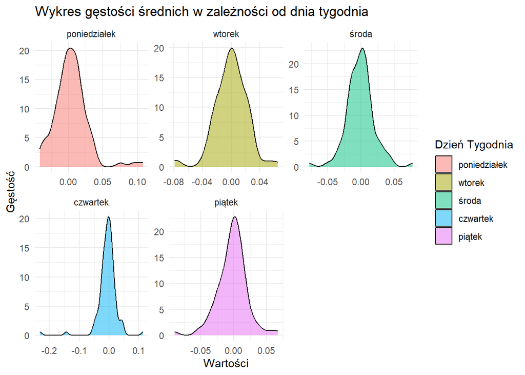

```r
wykres <- ggplot(dane, aes(x = `Stopa zwrotu`, fill = DzienTygodnia)) +
  geom_density(alpha = 0.5, position = "identity") +
  labs(title = "Wykres gęstości średnich w zależności od dnia tygodnia",
       x = "Wartości", y = "Gęstość", fill = "Dzień Tygodnia") +
  theme_minimal() +
  facet_wrap(~ DzienTygodnia, scales = "free")
wykres
```

Pokazane wykresy gęstości dobrze obrazują nam i potwierdzają wyciagnięte wcześniej wnioski, przede wszystkim widać mocną skośność prawostronną w poniedziałki, symetrię rozkładu środowego i dużą koncentrację obserwacji w czwartki.

### Wykres Pudełkowy

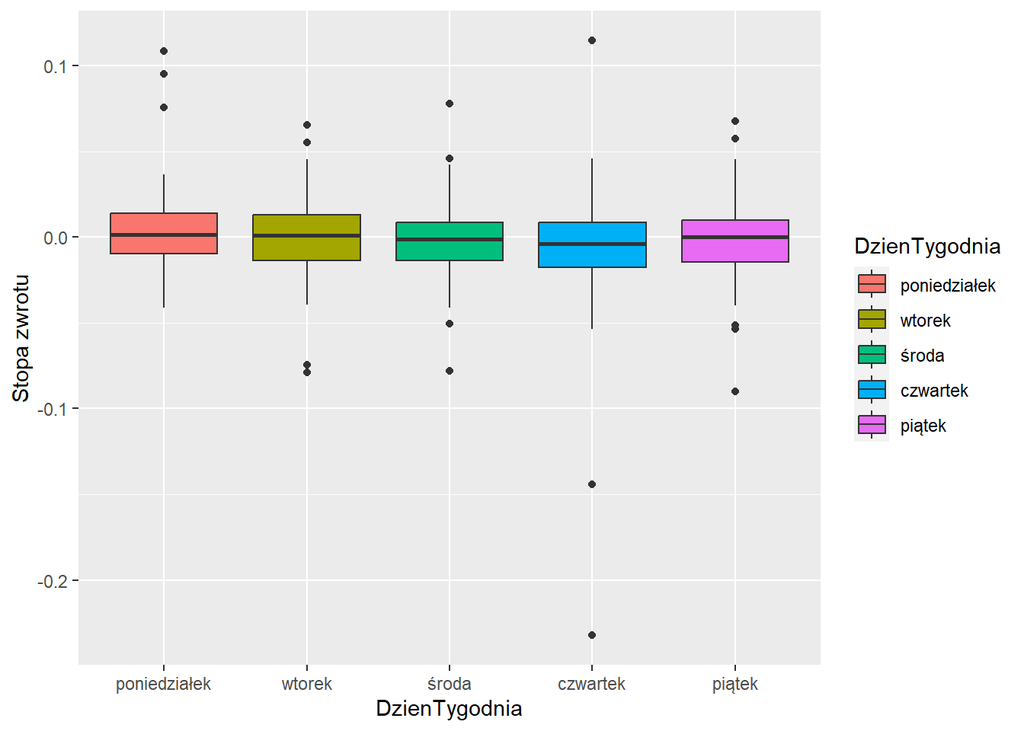

```r
pudelkowy <- ggplot(dane,aes(x=DzienTygodnia,y=`Stopa zwrotu`,fill=DzienTygodnia))+
  geom_boxplot()
pudelkowy
```

Na wykresie pudełkowym widzimy, że w każdym dniu tygodnia występują duże wartości odstające, co na pewno wpływa na negatywny wynik testu Shapiro-Wilka.

## **Porównaniu rozkładów stóp zwrotu we wtorki i piątki**

Porównania dokonamy testem Kołmogorowa-Smirnowa, czyli funkcji `ks.test()`, która jako argumenty przyjmuje badane rozkłady oraz rodzaj hipotezy alternatywnej, w naszym przypadku `"two.sided"`, gdyż sprawdzamy czy badane rozkłądy są takie same.

```r
ks.test(x = dane_piatek$`Stopa zwrotu`,dane_wtorek$`Stopa zwrotu`,
        alternative = "two.sided")
```

```
##
##  Asymptotic two-sample Kolmogorov-Smirnov test
##
## data:  dane_piatek$`Stopa zwrotu` and dane_wtorek$`Stopa zwrotu`
## D = 0.09, p-value = 0.8127
## alternative hypothesis: two-sided
```

Widzimy, że p-value wynosi 0.8127, co na przyjętym przez nas poziomie istotności $\alpha = 0.05$ świadczy o braku podstaw do odrzucenia hipotezy głównej, czyli rozkłady są bardzo podobne lub nawet takie same.

## **Porównanie wartości oczekiwanych stóp zwrotu we wtorki i piątki**

Z uwagi na to, że nie mamy do czynienia z rozkładem normalnym, do porównania wartości oczekiwanych stóp zwrotu we wtorki i piątki skorzystamy z funkcji `z.test()`, która pochodzi z pakietu `BSDA`. Ponadto zakładamy, że mamy do czynienia z dużą ilością danych. Jako arugmenty przyjmujemy kolejno: oba badane przez nas rozkłady, `mu = 0` oznaczające, że badamy równość wartości oczekiwanych, a następnie podajemy w argumentach `sigma.x` oraz `sigma.y` odchylenia standardowe obu populacji:

```r
z.test(dane_piatek$`Stopa zwrotu`, dane_wtorek$`Stopa zwrotu`,
       mu=0,alternative = "two.sided",
       sigma.x=sd(dane_piatek$`Stopa zwrotu`),sigma.y=sd(dane_wtorek$`Stopa zwrotu`))
```

```
##
##  Two-sample z-Test
##
## data:  dane_piatek$`Stopa zwrotu` and dane_wtorek$`Stopa zwrotu`
## z = -0.72995, p-value = 0.4654
## alternative hypothesis: true difference in means is not equal to 0
## 95 percent confidence interval:
##  -0.008443309  0.003860844
## sample estimates:
##     mean of x     mean of y
## -2.233174e-03  5.805868e-05
```

Z testu wynika, że nie ma podstaw do odrzucenia hipotezy głównej, na przyjętym przez nas poziomie istotności $\alpha = 0.05$, co oznacza, że wartości oczekiwane stóp zwrotu z wtorku i piątku nie różnią się istotnie.

# **WARIANT 2**

## **Wczytanie danych**

```r
dane13 <- read_excel("C:/Users/kanto/OneDrive/Pulpit/PROJEKT RPISM 2 CALOSC/DANE-PEPCO-JEDNATRZECIA.xlsx")
#jako ścieżkę w funkcji read_excel() należy podać swoją ścieżkę do podanego pliku z excela
head(dane13)
```

| Data | DzienTygodnia | Otwarcie | Najwyzszy | Najnizszy | Zamkniecie | Wolumen | Stopa zwrotu |
| --- | --- | --- | --- | --- | --- | --- | --- |
| 2022-01-03 | poniedziałek | 46.695 | 46.945 | 44.990 | 45.055 | 317607 | -0.031890876 |
| 2022-01-04 | wtorek | 45.840 | 46.450 | 45.285 | 46.300 | 147338 | 0.027257995 |
| 2022-01-05 | środa | 46.250 | 46.250 | 44.450 | 45.750 | 396004 | -0.011950169 |
| 2022-01-07 | piątek | 45.200 | 45.640 | 44.960 | 45.500 | 139778 | -0.005479466 |
| 2022-01-10 | poniedziałek | 45.500 | 45.580 | 44.605 | 44.780 | 71776 | -0.015950715 |
| 2022-01-11 | wtorek | 44.880 | 45.465 | 44.050 | 44.670 | 195926 | -0.002459476 |

```r
str(dane13)
```

```
## tibble [150 × 8] (S3: tbl_df/tbl/data.frame)
##  $ Data         : POSIXct[1:150], format: "2022-01-03" "2022-01-04" ...
##  $ DzienTygodnia: chr [1:150] "poniedziałek" "wtorek" "środa" "piątek" ...
##  $ Otwarcie     : num [1:150] 46.7 45.8 46.2 45.2 45.5 ...
##  $ Najwyzszy    : num [1:150] 46.9 46.5 46.2 45.6 45.6 ...
##  $ Najnizszy    : num [1:150] 45 45.3 44.5 45 44.6 ...
##  $ Zamkniecie   : num [1:150] 45.1 46.3 45.8 45.5 44.8 ...
##  $ Wolumen      : num [1:150] 317607 147338 396004 139778 71776 ...
##  $ Stopa zwrotu : num [1:150] -0.03189 0.02726 -0.01195 -0.00548 -0.01595 ...
```

Ponownie zmienimy niektóre typy zmiennych:

```r
dane13$Data <- as.Date(dane13$Data)
dane13$DzienTygodnia <- as.factor(dane13$DzienTygodnia)
dane13$DzienTygodnia <- factor(dane13$DzienTygodnia,
                               levels = c("poniedziałek", "wtorek", "środa", "czwartek", "piątek"))
```

## **Obliczenie charaktertystyk i normalność rozkładu**

### Charakterystyki i Normalność Rozkładu

Ponownie skorzystamy z wektorów, które zawierają wartości dla każdego dnia tygodnia osobno:

```r
dane_poniedzialek13 <- dane13[dane13$DzienTygodnia == "poniedziałek",]
dane_wtorek13 <- dane13[dane13$DzienTygodnia=="wtorek",]
dane_sroda13 <- dane13[dane13$DzienTygodnia=="środa",]
dane_czwartek13 <- dane13[dane13$DzienTygodnia=="czwartek",]
dane_piatek13 <- dane13[dane13$DzienTygodnia=="piątek",]
```

Korzystając ze stworzonej przez nas na początku funkcji, obliczymy podstawowe statystyki opisowe dla badanym rozkładów dla każdego dnia tygodnia osobno i wszystkich łącznie, jednakże tym razem wszystko dla $\frac{1}{3}$ wszystkich danych:

```r
generowanie_charakterystyki(dane13$`Stopa zwrotu`)
```

| Średnia | Odchylenie std. | Skośność | Kurtoza | Minimum | Maximum | Rozkładn nor. |
| --- | --- | --- | --- | --- | --- | --- |
| -0.00187 | 0.02119 | 0.28055 | 3.61819 | -0.05362 | 0.0755 | Tak |

```r
generowanie_charakterystyki(dane_poniedzialek13$`Stopa zwrotu`)
```

| Średnia | Odchylenie std. | Skośność | Kurtoza | Minimum | Maximum | Rozkładn nor. |
| --- | --- | --- | --- | --- | --- | --- |
| 0.00312 | 0.02599 | 0.57442 | 3.20271 | -0.0381 | 0.0755 | Tak |

W poniedziałki spółka średnio notowała zysk, o czym świadczy dodatnia wartość średniej logarytmicznych stóp zwrotu. Występuje dosyć silna skośność prawostronna (0.574), a kurtoza jest bliska 3 (3.2), test Shapiro-Wilka potwierdza, że dane pochodzą z rozkładu normalnego.

```r
generowanie_charakterystyki(dane_wtorek13$`Stopa zwrotu`)
```

| Średnia | Odchylenie std. | Skośność | Kurtoza | Minimum | Maximum | Rozkładn nor. |
| --- | --- | --- | --- | --- | --- | --- |
| -0.00468 | 0.01608 | 0.34183 | 2.44261 | -0.03174 | 0.02726 | Tak |

We wtorki średnio spółka notowała stratę. Kurtoza jest równa około 2.4, co świadczy o lekkim rozkładzie platokurtycznym, występuje również umiarkowana skośność prawostronna. Dane pochodzą z rozkładu normalnego.

```r
generowanie_charakterystyki(dane_sroda13$`Stopa zwrotu`)
```

| Średnia | Odchylenie std. | Skośność | Kurtoza | Minimum | Maximum | Rozkładn nor. |
| --- | --- | --- | --- | --- | --- | --- |
| -0.00243 | 0.01805 | 0.13773 | 2.99797 | -0.03301 | 0.03775 | Tak |

We środy spółka także odnotowuje średnio stratę. Kurtoza jest praktycznie równa 3, a skośność bliska 0 (delikatna prawostronna), dane pochodzą z rozkładu normalnego.

```r
generowanie_charakterystyki(dane_czwartek13$`Stopa zwrotu`)
```

| Średnia | Odchylenie std. | Skośność | Kurtoza | Minimum | Maximum | Rozkładn nor. |
| --- | --- | --- | --- | --- | --- | --- |
| -0.00338 | 0.0233 | 0.20253 | 2.72197 | -0.04811 | 0.04483 | Tak |

We czwartki spółka osiąga średnio stratę, kurtoza ponownie jest zbliżona do 3, występuje niewielka skośność prawostronna. Dane pochodzą z rozkładu normalnego.

```r
generowanie_charakterystyki(dane_piatek13$`Stopa zwrotu`)
```

| Średnia | Odchylenie std. | Skośność | Kurtoza | Minimum | Maximum | Rozkładn nor. |
| --- | --- | --- | --- | --- | --- | --- |
| -0.00202 | 0.02178 | -0.56998 | 3.64527 | -0.05362 | 0.04522 | Tak |

W piątki badana spółka również jak w pozostałych dniach średnio osiąga stratę, kurtoza w te dni tygodnia jest równa około 3.6, a skośność jest lewostronna o wartości około -0.57. Test Shapiro-Wilka wskazuje, że dane pochodzą z rozkładu normalnego.

### Wykres Gęstości

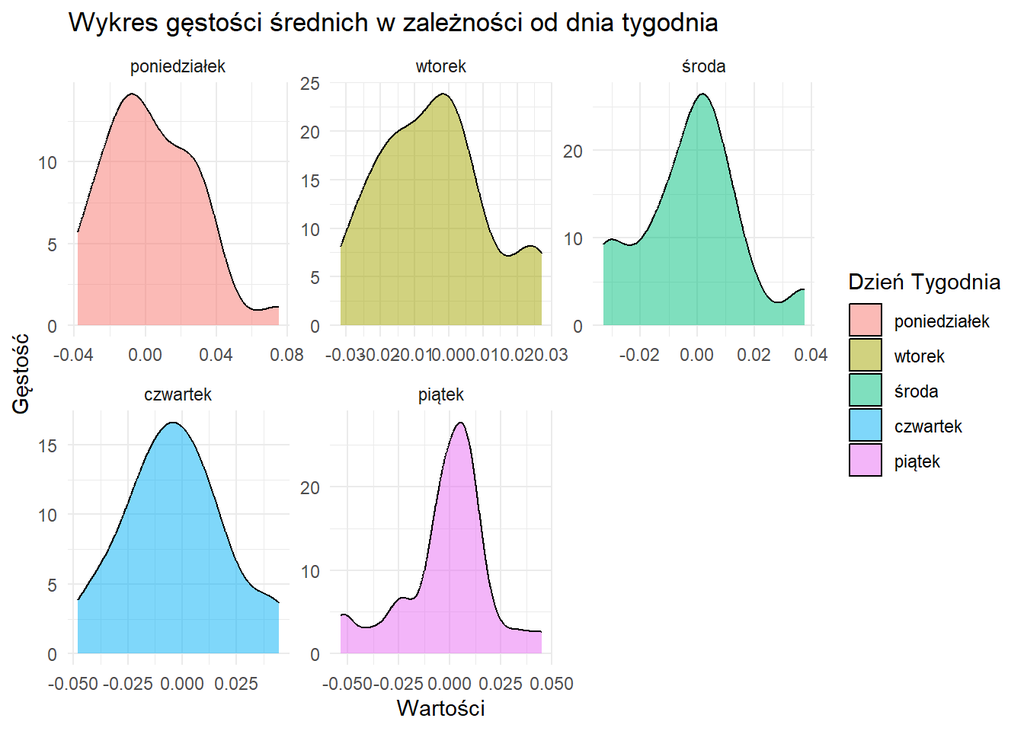

```r
wykres13 <- ggplot(dane13, aes(x = `Stopa zwrotu`, fill = DzienTygodnia)) +
  geom_density(alpha = 0.5, position = "identity") +
  labs(title = "Wykres gęstości średnich w zależności od dnia tygodnia",
       x = "Wartości", y = "Gęstość", fill = "Dzień Tygodnia") +
  theme_minimal() +
  facet_wrap(~ DzienTygodnia, scales = "free")
wykres13
```

### Wykres Pudełkowy

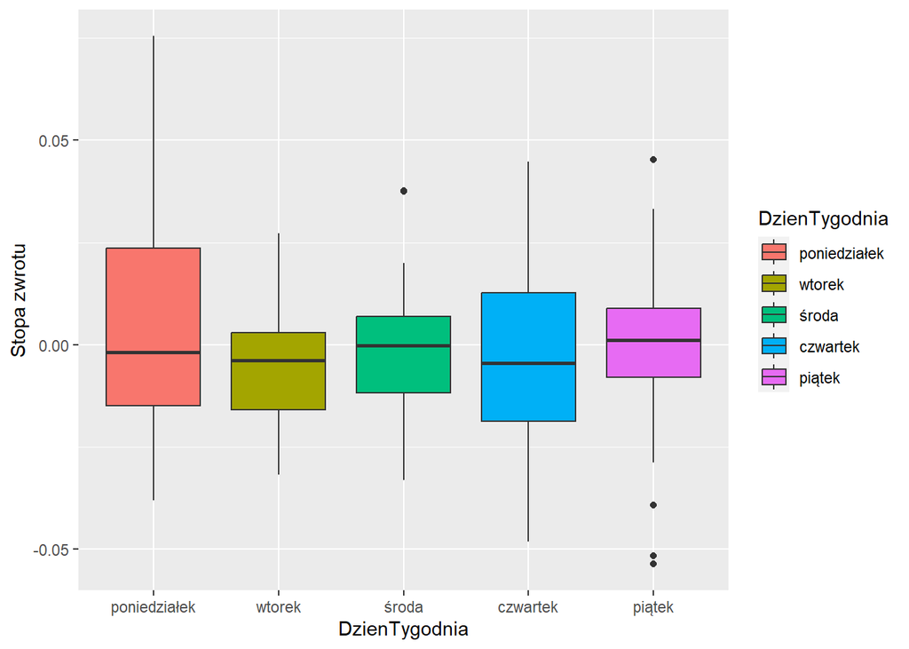

```r
pudelkowy13 <- ggplot(dane13,aes(x=DzienTygodnia,y=`Stopa zwrotu`,fill=DzienTygodnia))+
  geom_boxplot()
pudelkowy13
```

Na wykresie pudełkowym z wąsem zauważyć, że w porównaniu do całości danych, dla ich $\frac{1}{3}$ występuje mniej outlierów, a dane nie są aż tak skupione wokół mediany, o czym świadczą rozmiary pudełek.

## **Porównaniu rozkładów stóp zwrotu we wtorki i piątki**

Ponownie skorzystamy z funkcji `ks.test()`, która przeprowadza test Kołmogorowa-Smirnowa, badający podobieństwo rozkładów, u nas podobieństwo rozkładów stóp zwrotu we wtorki i piątki:

```r
ks.test(x = dane_piatek13$`Stopa zwrotu`,dane_wtorek13$`Stopa zwrotu`,
        alternative = "two.sided")
```

```
##
##  Exact two-sample Kolmogorov-Smirnov test
##
## data:  dane_piatek13$`Stopa zwrotu` and dane_wtorek13$`Stopa zwrotu`
## D = 0.23333, p-value = 0.3929
## alternative hypothesis: two-sided
```

Widzimy, że p-value wynosi 0.3929, co na przyjętym przez nas poziomie istotności $\alpha = 0.05$ świadczy o braku podstaw do odrzucenia hipotezy głównej, czyli rozkłady są bardzo podobne, lub takie same.

## **Porównanie wartości oczekiwanych stóp zwrotu we wtorki i piątki**

W tym przypadku, znając wyniki testu Shapiro-Wilka, mamy do czynienia z rozkładami normalnymi, więc do porównania wartości oczekiwanych stóp zwrotu we wtorki i piątki skorzystamy z funkcji `z.test()`, bez konieczności zakłożenia, że ilość obserwacji jest duża:

```r
z.test(dane_piatek13$`Stopa zwrotu`,
       dane_wtorek13$`Stopa zwrotu`,mu=0,alternative = "two.sided",
       sigma.x=sd(dane_piatek13$`Stopa zwrotu`),sigma.y=sd(dane_wtorek13$`Stopa zwrotu`))
```

```
##
##  Two-sample z-Test
##
## data:  dane_piatek13$`Stopa zwrotu` and dane_wtorek13$`Stopa zwrotu`
## z = 0.53888, p-value = 0.59
## alternative hypothesis: true difference in means is not equal to 0
## 95 percent confidence interval:
##  -0.007025355  0.012353411
## sample estimates:
##    mean of x    mean of y
## -0.002018993 -0.004683021
```

Z testu wynika, że nie ma podstaw do odrzucenia hipotezy głównej, na przyjętym przez nas poziomie istotności $\alpha = 0.05$, co oznacza, że wartości oczekiwane stóp zwrotu z wtorku i piątku nie różnią się istotnie.

# **WNIOSKI**

Możemy zauważyć, że w zależności od wielkości obserwacji, na której dokonujemy analizy, wyniki statystyk opisowych, jak również rozkłady różnią się od siebie istotnie. Gdy wzięliśmy $\frac{1}{3}$ obserwacji, wszystkie rozkłady były normalne, co ułatwiało przeprowadzanie testów, bez koniecznych założeń.